# Data Science - Homework #3

Jake Rozran

```r
library(tidyverse)
library(mosaicData) # For problem 2
library(babynames) # For problem 3
library(mdsr) # For problem 4
```

## Problem 1) Arrests Per State in the US

The `USArrests` dataset contains one observation per US State. The variables are the murder, assault, and rape rates per 100,000 people as well as the percent of the population living in urban areas.

**Problem 1a) Create a graph of murder rate.**

```r
data("USArrests")
head(USArrests)
```

```
##            Murder Assault UrbanPop Rape
## Alabama      13.2     236       58 21.2
## Alaska       10.0     263       48 44.5
## Arizona       8.1     294       80 31.0
## Arkansas      8.8     190       50 19.5
## California    9.0     276       91 40.6
## Colorado      7.9     204       78 38.7
```

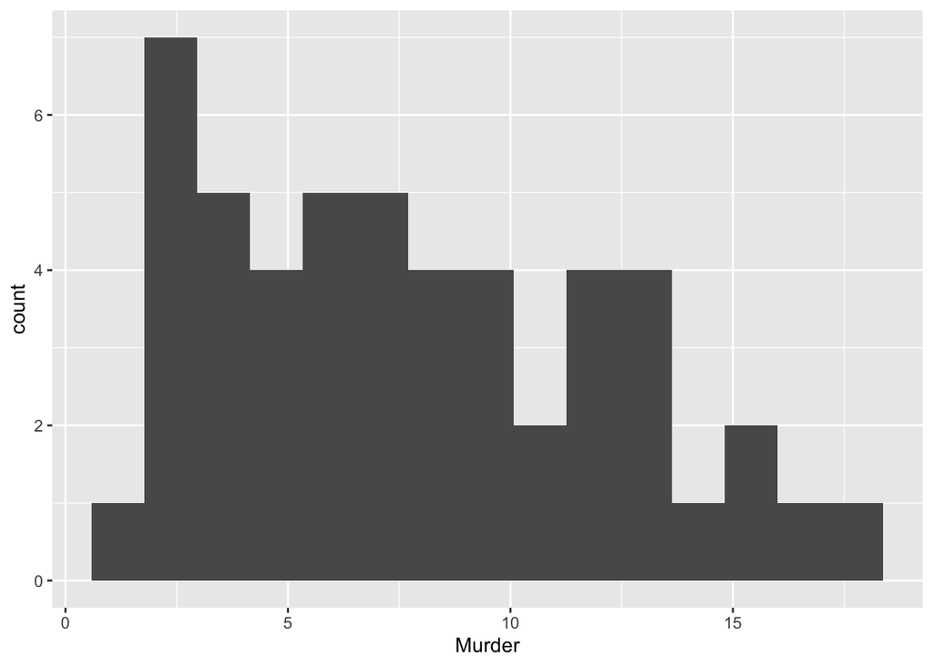

```r
ggplot(USArrests, aes(x = Murder)) +
    geom_histogram(bins = 15)
```

Unimodal, skewed right, no outliers.

**Problem 1b) Create a graph of assault rate.**

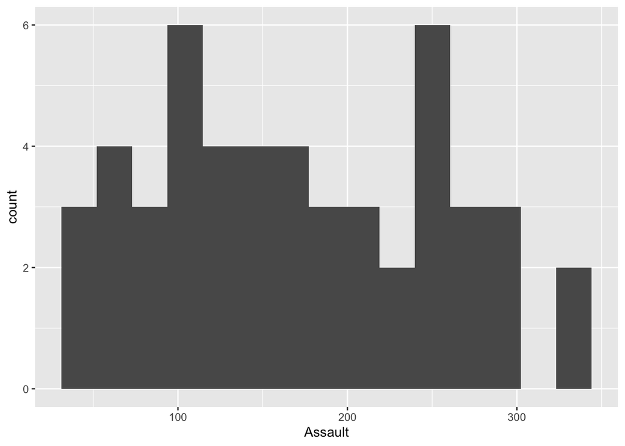

```r
ggplot(USArrests, aes(x = Assault)) +
    geom_histogram(bins = 15)
```

The plot is almost uniform with two modes (so… I guess we can say it is bimodal). No clear skew. No clear outliers.

**Problem 1c) Create a scatterplot of murder rate (`x`) vs. assault rate (`y`).**

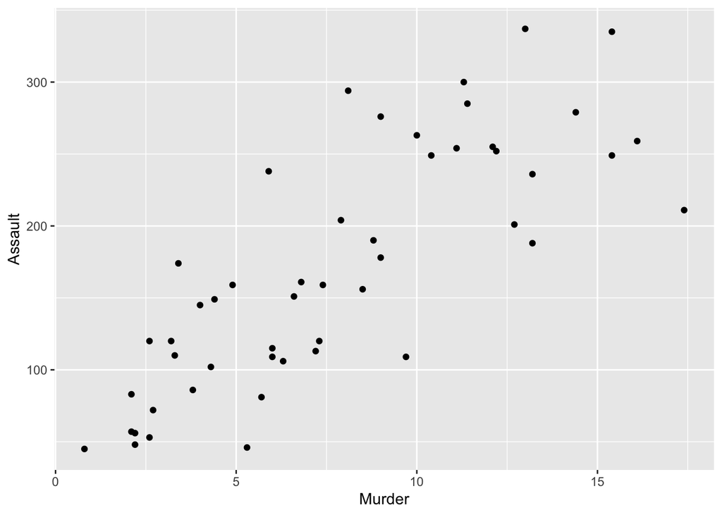

```r
ggplot(USArrests, aes(x = Murder, y = Assault)) +
    geom_point()
```

There is a clear positive correlation between Murder and Assault Rates. Strong, positive, linear relationship between the two variables. No clear outliers.

**Problem 1d) Add a `geom_smooth` to the previous plot.**

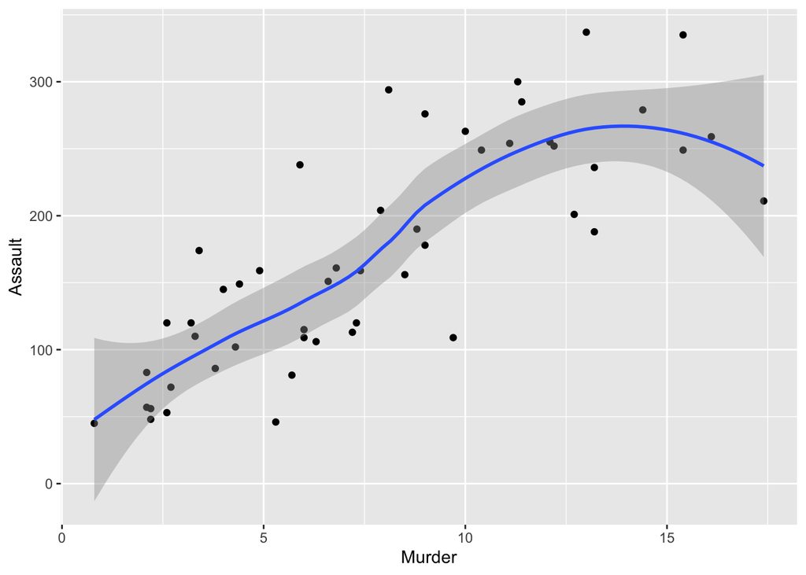

```r
ggplot(USArrests, aes(x = Murder, y = Assault)) +
    geom_point() +
    geom_smooth()
```

Adding the `geom_smooth` gives a generally linear regression line to the plot. It does seem, however, that the assault rates have an upper boundary of sorts, even as the murder rate increases.

**Problem 1e) Add another `geom_smooth` with a `method = "lm"` argument to the** **previous plot. (You might want to make it a different color to distinguish it** **from the previous one.)**

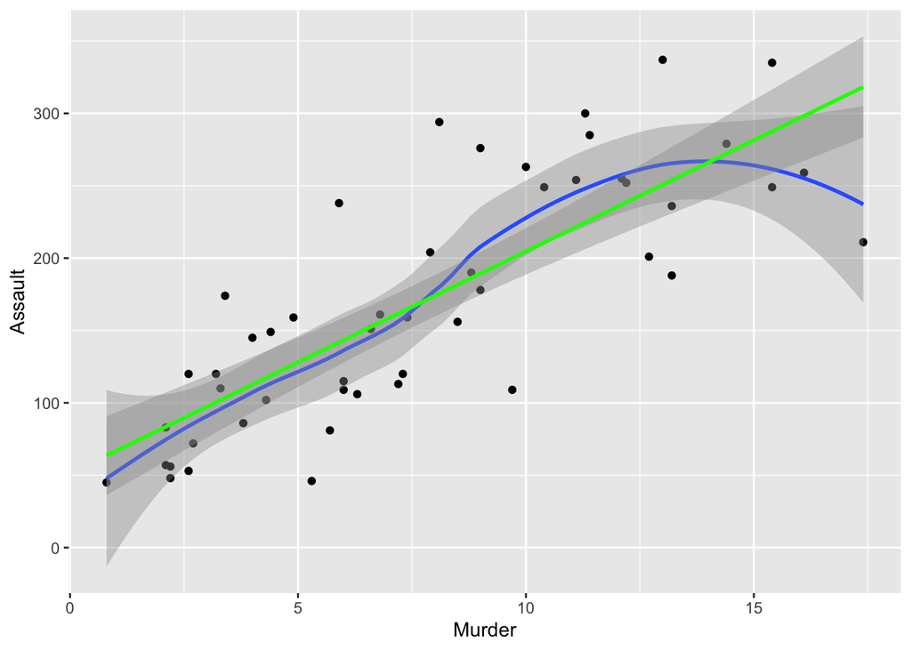

```r
ggplot(USArrests, aes(x = Murder, y = Assault)) +
    geom_point() +
    geom_smooth() +
    geom_smooth(method = "lm", color = "green")
```

A linear model does seem to be appropriate for these data. Aside from the deviation as murder rates reach their maximum, the lines are nearly identical. It is hard to tell from this graph, but I don’t think there is a true deviation from linear there…

**Problem 1f) Add `UrbanPop` as a color aesthetic to the scatterplot you created** **in 1c) above.**

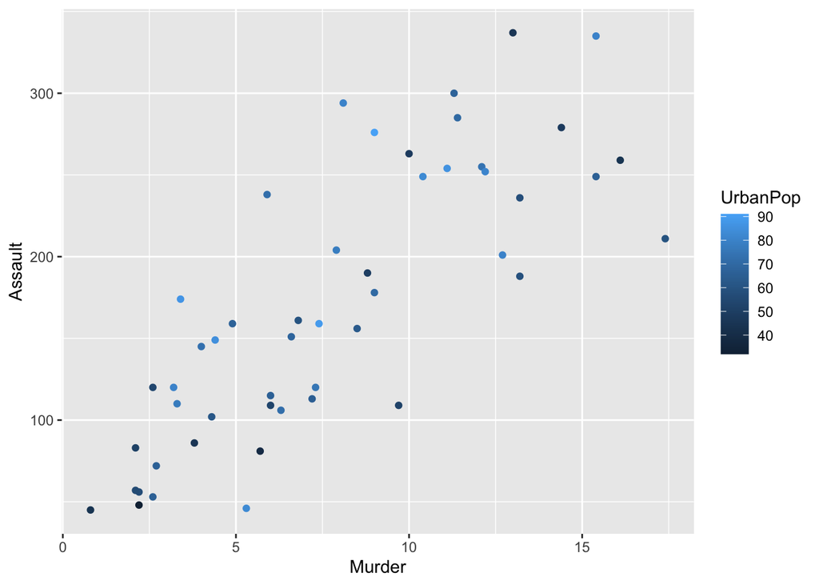

```r
ggplot(USArrests, aes(x = Murder, y = Assault, color = UrbanPop)) +
    geom_point()
```

It isn’t exactly easy to tell, but there seems to be a pretty random spread of urban population in the graph. I don’t see a clear correlation between urban population and either variable.

## Problem 2) Galton Height Data

The Galton data can be found in the `mosaicData` package. The data contains `height` information on all children within a `family`, including the child’s `sex` (gender), the `mother`’s height, the `father`’s height, and the number of kids (`nkids`) in the family. Height is measured in inches.

**Problem 2a) Create a scatterplot of each person’s height against their** **Father’s height. (As typically done, please put the independent variable on** **the x-axis)**

```r
data("Galton")
head(Galton)
```

```
##   family father mother sex height nkids
## 1      1   78.5   67.0   M   73.2     4
## 2      1   78.5   67.0   F   69.2     4
## 3      1   78.5   67.0   F   69.0     4
## 4      1   78.5   67.0   F   69.0     4
## 5      2   75.5   66.5   M   73.5     4
## 6      2   75.5   66.5   M   72.5     4
```

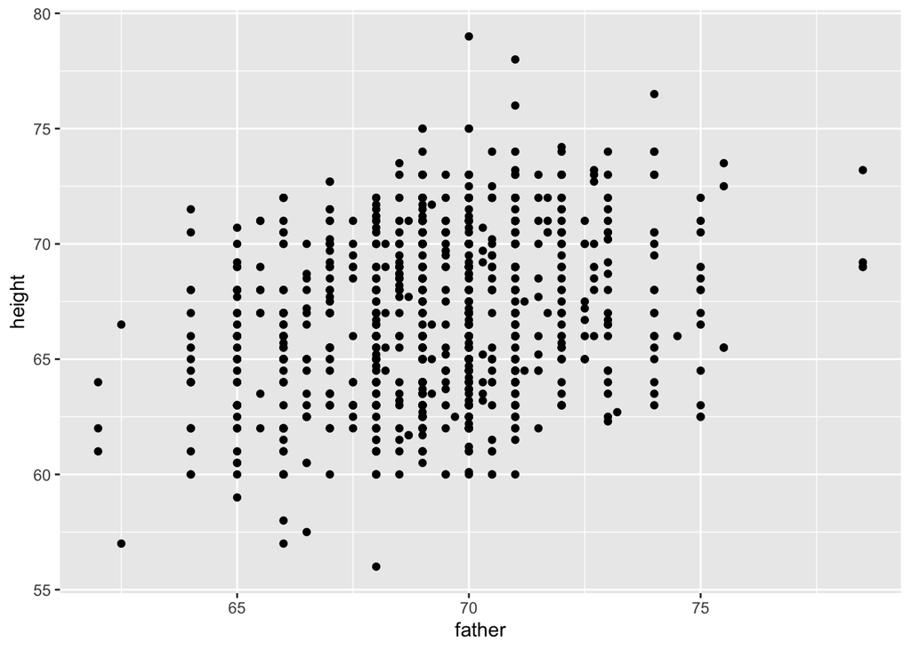

```r
ggplot(Galton, aes(x = father, y = height)) +
    geom_point()
```

There seems to be a positive, moderate strength, linear relationship between a father’s height and the child’s height.

**Problem 2b) Add a regression line to the previous plot by using** **`geom_smooth(method = "lm")`.**

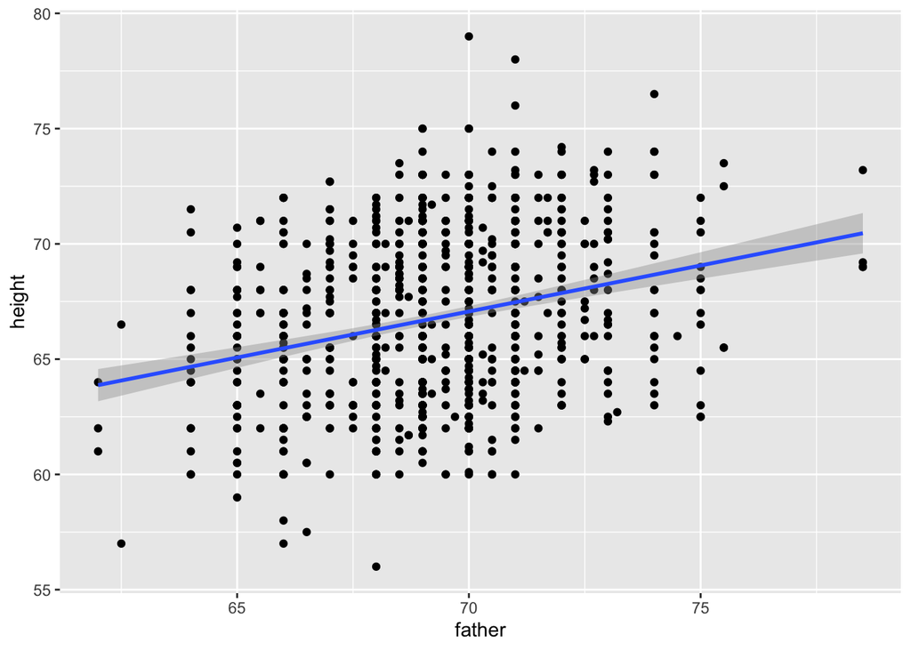

```r
ggplot(Galton, aes(x = father, y = height)) +
    geom_point() +
    geom_smooth(method = "lm")
```

The linear model fits ok. There relationship is not very strong, so there is quite a bit of spread from the lm. That said, the spread is rather equal.

**Problem 2c) Add a y = x line to the previous plot using** **`geom_abline(intercept = 0, slope = 1)`**

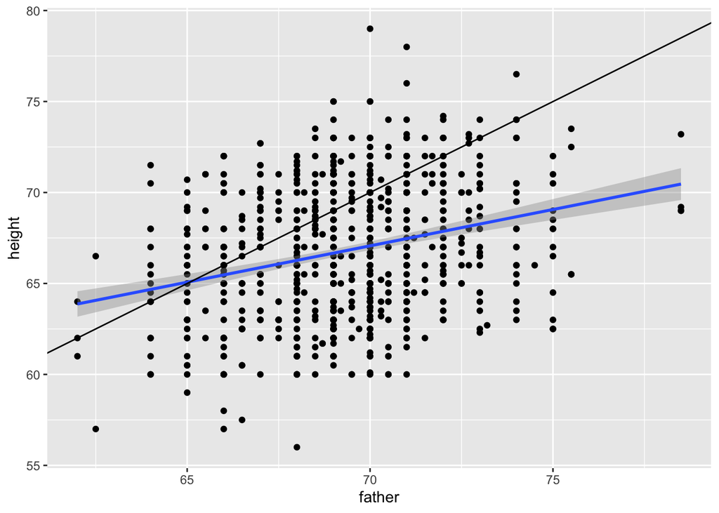

```r
ggplot(Galton, aes(x = father, y = height)) +
    geom_point() +
    geom_smooth(method = "lm") +
    geom_abline(intercept = 0, slope = 1)
```

There regression line is certainly much flatter than a = 1.

**Problem 2d) Add `sex` as an aesthethic to the previous plot. Make sure you** **have two separate regression lines, one per each `sex`.**

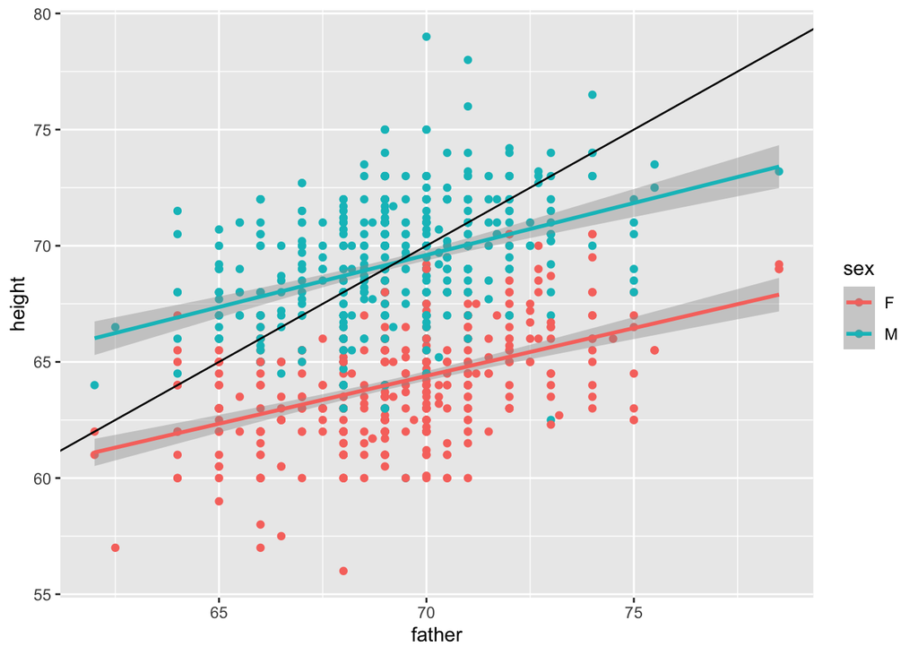

```r
ggplot(Galton, aes(x = father, y = height, color = sex)) +
    geom_point() +
    geom_smooth(method = "lm") +
    geom_abline(intercept = 0, slope = 1)
```

It is quite remarkable how the lines are parallel to one another. The difference is about 5 inches?